# Practical Machine Learning Course Project

**Created Sun Feb 22 17:02:29 2015**

R version 3.1.2 (2014-10-31)  
Platform: x86_64-pc-linux-gnu (64-bit)

## Problem description:

The goal of this project is to perform a quantitative analysis of *how well people wearing accelerometers perfoming their exercises*. To achieve that, we analyse the data received from accelerometers on the belt, forearm, arm, and dumbell of six participants. The participants perform barbell lifts correctly and incorrectly in five different ways. The data for this project is generously provided by **http://groupware.les.inf.puc-rio.br/har**.

# Loading data

Create ‘data’ folder in your workspace (if there is no such folder) and download the training and testing data.

```r
if (!file.exists("data")){
        dir.create("data")
        }

fileUrlTrain <- "https://d396qusza40orc.cloudfront.net/predmachlearn/pml-training.csv"
fileUrlTest <- "https://d396qusza40orc.cloudfront.net/predmachlearn/pml-testing.csv"

if (!file.exists("./data/pml-training.csv")){
        download.file(fileUrlTrain, destfile = "./data/pml-training.csv", method = "curl")
}
if (!file.exists("./data/pml-testing.csv")){
        download.file(fileUrlTest, destfile = "./data/pml-testing.csv", method = "curl")
}
```

Load the data sets

```r
# na.strings = c("NA","") acually makes cleaning easier yet I was lazy to redo the analysis :)
trainingInit <- read.csv("./data/pml-training.csv", header = TRUE, nrows = 20000)
testingFinal <- read.csv("./data/pml-testing.csv", header = TRUE)
```

# Cleaning the data

Let’s try to get only useful data from the data set before we start to perform our analysis. First of all, we don’t need timestamps, user names, indices (i.e., first 7 columns):

```r
summary(trainingInit)
```

```r
library(data.table)
trainingInit <- as.data.table(trainingInit)
testingFinal <- as.data.table(testingFinal)
trainingInit <- trainingInit[, -(1:7), with = FALSE]
testingFinal <- testingFinal[, -(1:7), with = FALSE]
dim(trainingInit); dim(testingFinal)
```

```
## [1] 19622   153
```

```
## [1]  20 153
```

Check the number of missing values in the data set

```r
sum.na <- function(x) {sum(is.na(x))}
tt <- trainingInit[, lapply(.SD, sum.na)]
table(unlist(tt))
```

```
##
##     0 19216
##    86    67
```

As we can see, all variables that contain missing values have exactly the same amount of them. Moreover, all missing values are at the same places (see below)

```r
nas <- trainingInit[, which(tt>0), with = FALSE]
nas <- nas[complete.cases(nas),]
dim(trainingInit)[1] - dim(nas)[1]
```

```
## [1] 19216
```

Only 406 rows from 19622 are contain meaningful data, which is just 2% of data. Therefore, we just remove this variables from the data sets. (Which might be a bad idea yet it will become clear after we perform the analysis. It might be the case that we will need to do some imputing instead.)

```r
trainingInit <- trainingInit[, -(which(tt>0)), with = FALSE]
testingFinal <- testingFinal[, -(which(tt>0)), with = FALSE]
dim(trainingInit); dim(testingFinal)
```

```
## [1] 19622    86
```

```
## [1] 20 86
```

Now lets get rid of variables that contain `'#DIV/0!'` values. (One can check that such variables do not contain meaningful data, yet we omit that part of our analysis from the report to save some space.)

```r
find.div0 <- function(x) { '#DIV/0!' %in% x}
tt <- trainingInit[, lapply(.SD, find.div0)]
trainingInit <- trainingInit[, -(which(tt == 'TRUE')), with = FALSE]
testingFinal <- testingFinal[, -(which(tt == 'TRUE')), with = FALSE]
dim(trainingInit); dim(testingFinal)
```

```
## [1] 19622    53
```

```
## [1] 20 53
```

```r
summary(trainingInit)
```

[output not shown]

# Analysis

First split our clean training data into training and testing sets. We will use the former to build a prediction model and the latter one to evaluate estimator performance (i.e., to check the out-of-sample error).

```r
library(caret)
set.seed(333)
inTrain <- createDataPartition(y = trainingInit$classe, p = 0.7, list = FALSE)
training <- trainingInit[inTrain[,1]]; testing <- trainingInit[-inTrain[,1]]
dim(testing); dim(training)
```

```
## [1] 5885   53
```

```
## [1] 13737    53
```

```r
# enabling parallel processing
library(doMC)
registerDoMC(cores = 4)
# fitting the model
modelFit <- train(classe ~ ., data = training, method = "rf", trControl = trainControl(method = "cv", number = 10), prox = TRUE, allowParallel = TRUE)
print(modelFit$finalModel)
```

```
##
## Call:
##  randomForest(x = x, y = y, mtry = param$mtry, proximity = TRUE,      allowParallel = TRUE)
##                Type of random forest: classification
##                      Number of trees: 500
## No. of variables tried at each split: 2
##
##         OOB estimate of  error rate: 0.71%
## Confusion matrix:
##      A    B    C    D    E class.error
## A 3901    4    0    0    1 0.001280082
## B   12 2637    9    0    0 0.007900677
## C    0   21 2372    3    0 0.010016694
## D    0    0   36 2214    2 0.016873890
## E    0    0    4    6 2515 0.003960396
```

Predicting new values (in testing data set) and check the confusion matrix

```r
pred <- predict(modelFit, testing)
C <- confusionMatrix(pred, testing$classe)
print(C)
```

```
## Confusion Matrix and Statistics
##
##           Reference
## Prediction    A    B    C    D    E
##          A 1674    5    0    0    0
##          B    0 1134    7    0    0
##          C    0    0 1017   19    0
##          D    0    0    2  944    5
##          E    0    0    0    1 1077
##
## Overall Statistics
##
##                Accuracy : 0.9934
##                  95% CI : (0.991, 0.9953)
##     No Information Rate : 0.2845
##     P-Value [Acc > NIR] : < 2.2e-16
##
##                   Kappa : 0.9916
##  Mcnemar's Test P-Value : NA
##
## Statistics by Class:
##
##                      Class: A Class: B Class: C Class: D Class: E
## Sensitivity            1.0000   0.9956   0.9912   0.9793   0.9954
## Specificity            0.9988   0.9985   0.9961   0.9986   0.9998
## Pos Pred Value         0.9970   0.9939   0.9817   0.9926   0.9991
## Neg Pred Value         1.0000   0.9989   0.9981   0.9959   0.9990
## Prevalence             0.2845   0.1935   0.1743   0.1638   0.1839
## Detection Rate         0.2845   0.1927   0.1728   0.1604   0.1830
## Detection Prevalence   0.2853   0.1939   0.1760   0.1616   0.1832
## Balanced Accuracy      0.9994   0.9971   0.9937   0.9889   0.9976
```

```r
varImp(modelFit)
```

```
## rf variable importance
##
##   only 20 most important variables shown (out of 52)
##
##                      Overall
## roll_belt             100.00
## yaw_belt               71.12
## magnet_dumbbell_z      62.56
## magnet_dumbbell_y      60.05
## pitch_forearm          56.43
## pitch_belt             53.64
## magnet_dumbbell_x      48.76
## roll_forearm           45.87
## magnet_belt_y          40.82
## accel_dumbbell_y       39.50
## roll_dumbbell          38.52
## magnet_belt_z          36.78
## accel_belt_z           36.34
## roll_arm               32.58
## accel_dumbbell_z       31.77
## accel_forearm_x        29.51
## gyros_dumbbell_y       27.58
## accel_dumbbell_x       25.43
## total_accel_dumbbell   24.92
## yaw_dumbbell           24.69
```

Another way to check that is using `randomForest` function (which, BTW, is the way faster that `train` with `"rf"` method).

```r
library(randomForest)
randfor <- randomForest(.outcome ~ ., data = training, importance = TRUE)
```

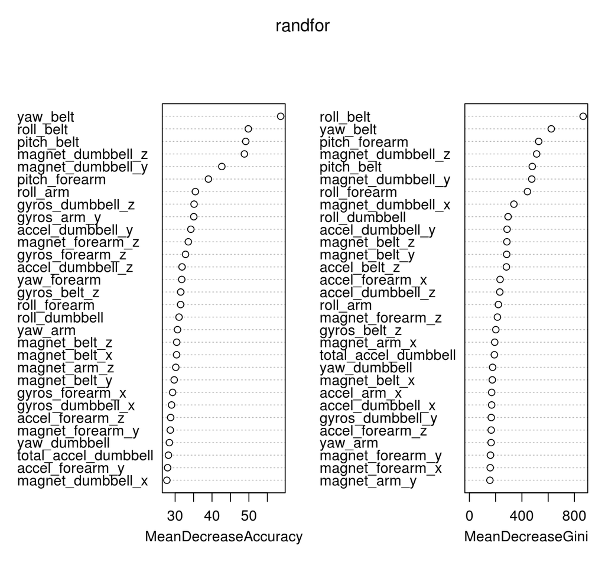

```r
varImpPlot(randfor)
```

We can probably fit another model with reduced number of predictors and get similar accuracy. Also, we could have used `randomForest` for fitting the model and `rfcv` function from the same package for cross validation (I have actually done that and they work muuuuch faster). However, we won’t change anything in this project as our prediction model seems to be rather good. Let’s now use it to predict `classe` variable for the original testing data set

```r
pred <- predict(modelFit, testingFinal)
pred <- as.vector(pred)
pred
```

```
##  [1] "B" "A" "B" "A" "A" "E" "D" "B" "A" "A" "B" "C" "B" "A" "E" "E" "A"
## [18] "B" "B" "B"
```

```r
pml_write_files(pred)
```

Which gives us 20/20 total score after submission.